# 第8章 製品開発

更新：2026-05-13

## 個人データ

#### conjoint1.txt

```r
conjoint1 <- read.table("dataset/conjoint1.txt", header = T)
```

- 元データの列名は「6時間」や「2年」で作成されているが，列名の先頭文字に数値は避けた方がよい
- 列名の先頭文字に数値の場合は `read.table` 関数はデータ読込時に列名の先頭に “X” を自動で追加する

| カードNo. | X6時間 | X4時間 | X2年 | 赤 | シルバー | 選好順位 | 全体効用 |
| --- | --- | --- | --- | --- | --- | --- | --- |
| 1 | 1 | 0 | 0 | 1 | 0 | 7 | 12 |
| 2 | 1 | 0 | 0 | 0 | 1 | 9 | 10 |
| 3 | 1 | 0 | 0 | 0 | 0 | 17 | 2 |
| 4 | 1 | 0 | 1 | 1 | 0 | 1 | 18 |
| 5 | 1 | 0 | 1 | 0 | 1 | 6 | 13 |
| 6 | 1 | 0 | 1 | 0 | 0 | 8 | 11 |
| 7 | 0 | 1 | 0 | 1 | 0 | 10 | 9 |
| 8 | 0 | 1 | 0 | 0 | 1 | 12 | 7 |
| 9 | 0 | 1 | 0 | 0 | 0 | 16 | 3 |
| 10 | 0 | 1 | 1 | 1 | 0 | 2 | 17 |

[output cut: 8 more lines]

## 4.2 個人分析

```r
result1 <- lm(全体効用 ~ X2年 + X4時間 + X6時間 + シルバー + 赤, data = conjoint1)
summary(result1)
```

```
##
## Call:
## lm(formula = 全体効用 ~ X2年 + X4時間 + X6時間 + シルバー +
##     赤, data = conjoint1)
##
## Residuals:
##     Min      1Q  Median      3Q     Max
## -3.0556 -0.8889  0.4167  1.0278  2.4444
##
## Coefficients:
##             Estimate Std. Error t value Pr(>|t|)
## (Intercept)  -0.5556     1.0199  -0.545  0.59591
## X2年          6.7778     0.8327   8.139 3.15e-06 ***
## X4時間        2.5000     1.0199   2.451  0.03052 *
## X6時間        3.5000     1.0199   3.432  0.00497 **
## シルバー      6.3333     1.0199   6.210 4.52e-05 ***
## 赤            7.6667     1.0199   7.517 7.07e-06 ***
## ---
## Signif. codes:  0 '***' 0.001 '**' 0.01 '*' 0.05 '.' 0.1 ' ' 1
##
## Residual standard error: 1.766 on 12 degrees of freedom
## Multiple R-squared:  0.9227, Adjusted R-squared:  0.8905
## F-statistic: 28.65 on 5 and 12 DF,  p-value: 2.819e-06
```

- 重回帰分析（`lm` 関数）でコンジョイント分析を行う場合，部分効用や重要度は手計算かExcelを利用した方が早い。グラフ化も同様。
- 後述の conjoint パッケージを利用すれば，直行表の作成から部分効用，重要度の計算まで一括で行うことができる。

#### 補足

教科書の分析データでは属性の水準（説明変数）を複数の列に分けて 1 or 0 の数値データとして記録しているが，lm 関数は文字の列を自動でダミー変数化してくれるため，以下のように属性と水準を文字のまま記録したデータでも同じ結果を得られる。

| カードNo. | バッテリ | 保証期間 | 色 | 選好順位 | 全体効用 |
| --- | --- | --- | --- | --- | --- |
| 1 | 6時間 | 1年 | 赤 | 7 | 12 |
| 2 | 6時間 | 1年 | シルバー | 9 | 10 |
| 3 | 6時間 | 1年 | 黒 | 17 | 2 |
| 4 | 6時間 | 2年 | 赤 | 1 | 18 |
| 5 | 6時間 | 2年 | シルバー | 6 | 13 |
| 6 | 6時間 | 2年 | 黒 | 8 | 11 |
| 7 | 4時間 | 1年 | 赤 | 10 | 9 |
| 8 | 4時間 | 1年 | シルバー | 12 | 7 |
| 9 | 4時間 | 1年 | 黒 | 16 | 3 |
| 10 | 4時間 | 2年 | 赤 | 2 | 17 |

[output cut: 8 more lines]

```r
# 文字列説明変数の重回帰分析
result <- lm(全体効用 ~ 保証期間 + バッテリ + 色, data = conjoint1_text)
summary(result)
```

```
##
## Call:
## lm(formula = 全体効用 ~ 保証期間 + バッテリ + 色,
##     data = conjoint1_text)
##
## Residuals:
##     Min      1Q  Median      3Q     Max
## -3.0556 -0.8889  0.4167  1.0278  2.4444
##
## Coefficients:
##               Estimate Std. Error t value Pr(>|t|)
## (Intercept)     5.7778     1.0199   5.665 0.000105 ***
## 保証期間2年     6.7778     0.8327   8.139 3.15e-06 ***
## バッテリ4時間   2.5000     1.0199   2.451 0.030520 *
## バッテリ6時間   3.5000     1.0199   3.432 0.004969 **
## 色黒           -6.3333     1.0199  -6.210 4.52e-05 ***
## 色赤            1.3333     1.0199   1.307 0.215585
## ---
## Signif. codes:  0 '***' 0.001 '**' 0.01 '*' 0.05 '.' 0.1 ' ' 1
##
## Residual standard error: 1.766 on 12 degrees of freedom
## Multiple R-squared:  0.9227, Adjusted R-squared:  0.8905
## F-statistic: 28.65 on 5 and 12 DF,  p-value: 2.819e-06
```

教科書とは”色”属性の基準が異なるため，教科書の例と係数の値は異なる。 ただし，ダミー変数の定義から，この推定値でも部分効用や重要度を計算すると教科書と同じ数値が得られる。

```r
# 属性の基準を指定する場合
conjoint1_text$バッテリ <- relevel(factor(conjoint1_text$バッテリ), ref = "2時間")
conjoint1_text$保証期間 <- relevel(factor(conjoint1_text$保証期間), ref = "1年")
conjoint1_text$色 <- relevel(factor(conjoint1_text$色), ref = "黒")

result <- lm(全体効用 ~ 保証期間 + バッテリ + 色, data = conjoint1_text)
summary(result)
```

```
##
## Call:
## lm(formula = 全体効用 ~ 保証期間 + バッテリ + 色,
##     data = conjoint1_text)
##
## Residuals:
##     Min      1Q  Median      3Q     Max
## -3.0556 -0.8889  0.4167  1.0278  2.4444
##
## Coefficients:
##               Estimate Std. Error t value Pr(>|t|)
## (Intercept)    -0.5556     1.0199  -0.545  0.59591
## 保証期間2年     6.7778     0.8327   8.139 3.15e-06 ***
## バッテリ4時間   2.5000     1.0199   2.451  0.03052 *
## バッテリ6時間   3.5000     1.0199   3.432  0.00497 **
## 色シルバー      6.3333     1.0199   6.210 4.52e-05 ***
## 色赤            7.6667     1.0199   7.517 7.07e-06 ***
## ---
## Signif. codes:  0 '***' 0.001 '**' 0.01 '*' 0.05 '.' 0.1 ' ' 1
##
## Residual standard error: 1.766 on 12 degrees of freedom
## Multiple R-squared:  0.9227, Adjusted R-squared:  0.8905
## F-statistic: 28.65 on 5 and 12 DF,  p-value: 2.819e-06
```

### 部分効用

```r
# 回帰係数の確認・抽出
coef <- coef(result1)
print(coef)
```

```
## (Intercept)        X2年      X4時間      X6時間    シルバー          赤
##  -0.5555556   6.7777778   2.5000000   3.5000000   6.3333333   7.6666667
```

```r
# 保証期間
warranty <- c(coef["X2年"], "1年" = 0)
warranty <- warranty - mean(warranty)
print(warranty)
```

```
##      X2年       1年
##  3.388889 -3.388889
```

```r
# バッテリ時間
battery <- c(coef[c("X6時間", "X4時間")], "2時間" = 0)
battery <- battery - mean(battery)
print(battery)
```

```
## X6時間 X4時間  2時間
##    1.5    0.5   -2.0
```

```r
# 色
color <- c(coef[c("赤", "シルバー")], "黒" = 0)
color <- color - mean(color)
print(color)
```

```
##        赤  シルバー        黒
##  3.000000  1.666667 -4.666667
```

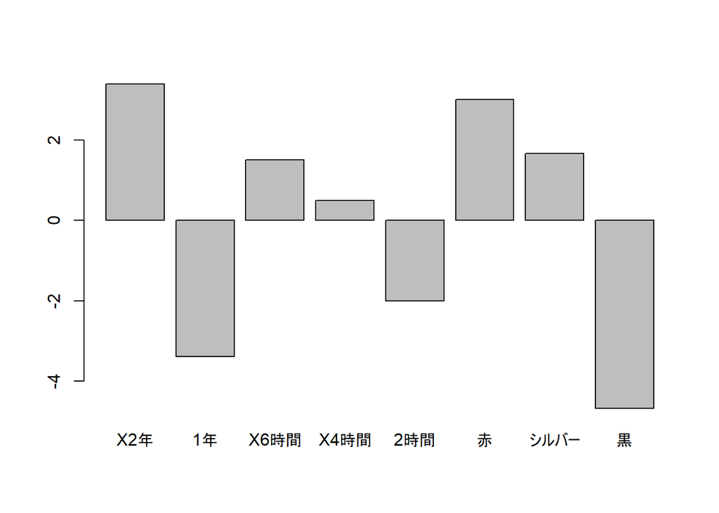

```r
# グラフ
ut <- c(warranty, battery, color)
barplot(ut)
```

### 重要度

```r
importance <- c(warranty = max(warranty) - min(warranty),
                battery = max(battery) - min(battery),
                color = max(color) - min(color))

importance <- importance/sum(importance)
print(importance)
```

```
##  warranty   battery     color
## 0.3777090 0.1950464 0.4272446
```

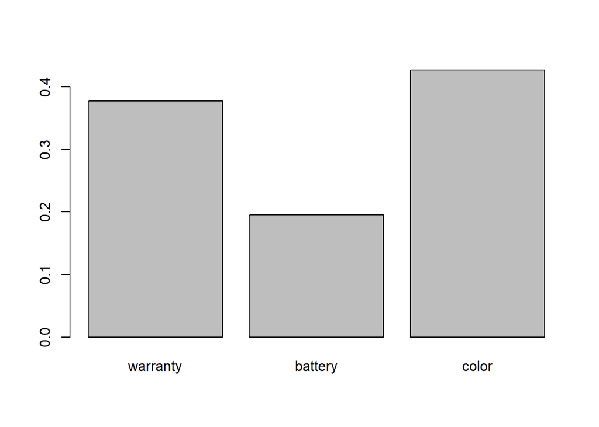

```r
# グラフ
barplot(importance)
```

## 直交表データ

#### conjoint2.txt

```r
conjoint2 <- read.table("dataset/conjoint2.txt", header = T)
```

| 回答者id | カードNo. | X2年 | X6時間 | X4時間 | 赤 | シルバー | 全体効用 | 順位 |
| --- | --- | --- | --- | --- | --- | --- | --- | --- |
| 1 | 1 | 1 | 1 | 0 | 1 | 0 | 9 | 1 |
| 1 | 2 | 1 | 0 | 1 | 0 | 1 | 7 | 3 |
| 1 | 3 | 1 | 0 | 0 | 0 | 0 | 3 | 7 |
| 1 | 4 | 0 | 1 | 0 | 0 | 1 | 5 | 5 |
| 1 | 5 | 0 | 0 | 1 | 0 | 0 | 2 | 8 |
| 1 | 6 | 0 | 0 | 0 | 1 | 0 | 4 | 6 |
| 1 | 7 | 1 | 1 | 0 | 0 | 0 | 1 | 9 |
| 1 | 8 | 1 | 0 | 1 | 1 | 0 | 8 | 2 |
| 1 | 9 | 1 | 0 | 0 | 0 | 1 | 6 | 4 |
| 2 | 1 | 1 | 1 | 0 | 1 | 0 | 9 | 1 |

[output cut: 80 more lines]

## 5.3 集計分析

```r
result2 <- lm(全体効用 ~ X2年 + X4時間 + X6時間 + シルバー + 赤, data = conjoint2)
summary(result2)
```

```
##
## Call:
## lm(formula = 全体効用 ~ X2年 + X4時間 + X6時間 + シルバー +
##     赤, data = conjoint2)
##
## Residuals:
##     Min      1Q  Median      3Q     Max
## -2.7667 -0.6875 -0.1500  0.5833  2.7000
##
## Coefficients:
##             Estimate Std. Error t value Pr(>|t|)
## (Intercept)   0.1667     0.3193   0.522 0.603020
## X2年          2.2500     0.2560   8.790 1.57e-13 ***
## X4時間        1.1333     0.2956   3.834 0.000243 ***
## X6時間        0.3667     0.2956   1.240 0.218245
## シルバー      3.9000     0.2956  13.194  < 2e-16 ***
## 赤            4.6000     0.2956  15.563  < 2e-16 ***
## ---
## Signif. codes:  0 '***' 0.001 '**' 0.01 '*' 0.05 '.' 0.1 ' ' 1
##
## Residual standard error: 1.145 on 84 degrees of freedom
## Multiple R-squared:  0.8165, Adjusted R-squared:  0.8056
## F-statistic: 74.77 on 5 and 84 DF,  p-value: < 2.2e-16
```

部分効用と重要度の計算は個人分析と同じ方法で計算できるため省略。

## 参考1：conjoint パッケージ

### 個人データ (conjoint1.txt) の分析

```r
library(conjoint)

# 属性・水準の定義
attribute <- list(color = c("red", "silver", "black"),
                  warranty = c("1year", "2year"),
                  battery = c("6hour", "4hour", "2hour"))

# ラベル名
label_name <- c("red", "silver", "black", "1year", "2year", "6hour", "4hour", "2hour")

# コンジョイントカードの作成（全組み合わせ）
experiment <- expand.grid(attribute)
full_profiles <- caFactorialDesign(experiment, type = "full")
print(full_profiles)

# コンジョイント分析の実行（全組み合わせ）
Conjoint(conjoint1$全体効用, full_profiles, label_name, y.type = "score")
```

#### コンジョイントカード

```
##     color warranty battery
## 1     red    1year   6hour
## 2  silver    1year   6hour
## 3   black    1year   6hour
## 4     red    2year   6hour
## 5  silver    2year   6hour
## 6   black    2year   6hour
## 7     red    1year   4hour
## 8  silver    1year   4hour
## 9   black    1year   4hour
## 10    red    2year   4hour
## 11 silver    2year   4hour
## 12  black    2year   4hour
## 13    red    1year   2hour
## 14 silver    1year   2hour
## 15  black    1year   2hour
## 16    red    2year   2hour
## 17 silver    2year   2hour
## 18  black    2year   2hour
```

#### 分析結果

```
##
## Call:
## lm(formula = frml)
##
## Residuals:
##     Min      1Q  Median      3Q     Max
## -3,0556 -0,8889  0,4167  1,0278  2,4444
##
## Coefficients:
##                     Estimate Std. Error t value Pr(>|t|)
## (Intercept)           9,5000     0,4164  22,817 2,98e-11 ***
## factor(x$color)1      3,0000     0,5888   5,095 0,000264 ***
## factor(x$color)2      1,6667     0,5888   2,831 0,015161 *
## factor(x$warranty)1  -3,3889     0,4164  -8,139 3,15e-06 ***
## factor(x$battery)1    1,5000     0,5888   2,547 0,025584 *
## factor(x$battery)2    0,5000     0,5888   0,849 0,412414
## ---
## Signif. codes:  0 '***' 0,001 '**' 0,01 '*' 0,05 '.' 0,1 ' ' 1
##
## Residual standard error: 1,766 on 12 degrees of freedom
## Multiple R-squared:  0,9227, Adjusted R-squared:  0,8905
## F-statistic: 28,65 on 5 and 12 DF,  p-value: 2,819e-06
```

```
## [1] "Part worths (utilities) of levels (model parameters for whole sample):"
##      levnms    utls
## 1 intercept     9,5
## 2       red       3
## 3    silver  1,6667
## 4     black -4,6667
## 5     1year -3,3889
## 6     2year  3,3889
## 7     6hour     1,5
## 8     4hour     0,5
## 9     2hour      -2
## [1] "Average importance of factors (attributes):"
## [1] 42,72 37,77 19,50
## [1] Sum of average importance:  99,99
## [1] "Chart of average factors importance"
```

- conjoint パッケージの回帰分析では部分効用（平均偏差形）が直接推定される
- 基準水準を含む部分効用（平均偏差形）は “Part worths (utilities) of levels (model parameters for whole sample):”
- 重要度は “Average importance of factors (attributes):”
- 本ページでは省略しているが，部分効用と重要度の図（教科書p.181）も出力される

### 直行表の作成

```r
library(conjoint)

# 属性・水準の定義
attribute <- list(color = c("red", "silver", "black"),
                  warranty = c("1year", "2year"),
                  battery = c("6hour", "4hour", "2hour"))

# コンジョイントカードの作成（直行表）
experiment <- expand.grid(attribute)
orth <- caFactorialDesign(experiment, type = "orthogonal")
print(orth)
```

```
##     color warranty battery
## 1     red    1year   6hour
## 3   black    1year   6hour
## 5  silver    2year   6hour
## 7     red    1year   4hour
## 12  black    2year   4hour
## 14 silver    1year   2hour
## 15  black    1year   2hour
## 16    red    2year   2hour
```

- 教科書の直行表と conjoint パッケージで作成される直行表は若干異なり，教科書データを使った分析ができないため，ここでは直行表の作成方法の紹介までとする
- 直行表を使った集計分析の方法は conjoint パッケージのヘルプ（Rで `??conjoint` を実行）を参照するか，ネットで検索
- **教科書の直行表の一部は間違っているようなので利用しないこと**